# Manipulating Objects in gmwm

# Introduction

The objective of this document is to provide users background information on the supported data objects within the `gmwm` ecosystem. The document provides information on how the different data types to use when loading a data set, how to create a model statement, and how to work with the computational results.

# Data Storage Objects

This section details the different kinds of objects recognized to store ones data. The section breaksdown the object and the benefits of using it.

## `gts` object

The `gts` object is the `gmwm` package’s equivalent to the `ts` object in R. There are a few differences between the two objects. Most notably, the unit conversion ability of the `gts` object. Furthermore, the `gts` object’s plotting functionality uses `ggplot2` instead of the `base` plotting library making cleaner graphs.

### Loading data into a `gts`

To populate a `gts` object there are two options:

1. Supply your own data

```r
vals = rnorm(100)

# Basic
ex1.basic = gts(vals)

# Advanced
ex1.adv = gts(vals, freq = 2, unit = "sec", name = "Example 1 Data")
```

2. Generate data according to an underlying process

```r
N = 1000
model = WN(sigma2=1) + AR1(phi = 0.1, sigma2 = .7)

# Basic
ex2.basic = gen.gts(model, N)

# Advanced
ex2.adv = gen.gts(model, freq = 10, unit = "sec", name = "Example 2 Data")
```

Within these data load options, you can supply additional information to generate an advanced `gts` object:

1. `freq`: The frequency of the data
   - We assume that the **frequency of an object is 1.**
2. `unit`: The unit the data was written in.
   - By default, **no unit** is associated with your data.
3. `name`: A name to be associated with your dataset
   - Data sets without a name will have it autogenerated within the plot function as `"Data Set X"`, where `"X"` denotes a number

### Working with `gts`

To use the `gts` object in your own code, there are a few helpful functions:

1. Detect whether or not the object is gts

```r
is.gts(x)
```

2. Find out the length of the time series

```r
length(x)
nrow(x)
```

### Graphing with `gts`

To create a graph with the `gts` object use:

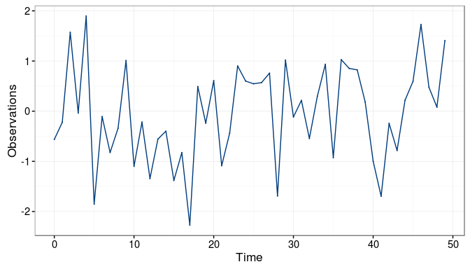

```r
x = gen.gts(WN(sigma2=1), 50)
plot(x)
```

This can be improved by doing:

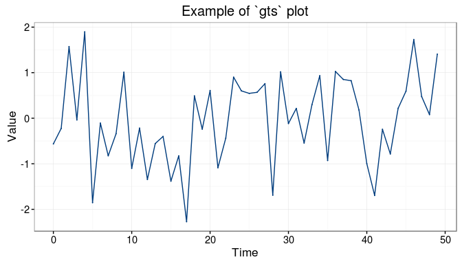

```r
plot(x, title = "Example of `gts` plot", axis.x.label = "Time", axis.y.label = "Value")
```

## `imu` object

The `imu` object is meant to act as a means to provide structure to an inertial measurement unit (IMU) data set. Using this structure enables an automatical modeling selection procedure through `auto`. Furthermore, we are able to provide a more customized visual graph for each of the sensors.

### Loading data into an `imu`

To populate an `imu` object there are two options:

1. Supply your own data already imported into R

```r
N = 10000
vals = cbind(rnorm(N),
             rnorm(N, mean = 3, sd = 1),
             rnorm(N, mean = 2, sd = 3),
             rnorm(N, mean = 1, sd = 2))

# Basic
x = imu(vals,
        gyros = 1:2,
        accels = 3:4)

# Advanced
x = imu(vals,
        gyros = 1:2,
        accels = 3:4,
        axis = c("A","B","A","B"),
        freq = 5, unit = "sec", name = "Example 3 Data")
```

2. Load in an IMU binary file

```r
# Option 1: Relative Directory
setwd("C:/Users/James")
x = read.imu("Documents/imu_data.imu", type = "IXSEA")

# Option 2: Fixed Directory
x = read.imu("C:/Users/James/Documents/imu_data.imu", type = "IXSEA")
```

The binary file reader currently supports the binary record format accepted by well known commercial software from Applanix (PosProc - developed by Bruno Scherzinger) or Novatel/Waypoint (IExplorer). This format is aptly described as a seven column layout where the first column of the data contains time data, columns 2-4 contain gyroscope values and columns 5-7 contain accelerometer values for axes X, Y, and Z. On load, appropriate scaling factors are applied to the data. This input format is valid for the following IMUs:

- IMAR
- LN200
- LN200IG
- IXSEA
- NAVCHIP_INT
- NAVCHIP_FLT

As was the case with the `gts` object, you can supply additional information to generate an advanced `imu` object such as:

1. `freq`: The frequency of the data
   - We assume that the **frequency of an object is 1.**
2. `unit`: The unit the data was written in.
   - By default, **no unit** is associated with your data.
3. `name`: A name to be associated with your dataset
   - Data sets without a name will have it autogenerated within the plot function as `"Data Set X"`, where `"X"` denotes a number

### Working with `imu`

To use the `imu` object in your own code, there are a few helpful functions:

1. Detect whether or not the object is `imu`

```r
is.imu(x)
```

2. Find out the length of the group of time series

```r
nrow(x)
```

3. Find out the number of columns

```r
ncol(x)
length(x)
```

4. Find out the sensors in the `imu` object

```r
# Numeric Return
value(x,"accel")   # Number of Accelerometers
value(x,"gyro")    # Number of Gyroscopes
value(x,"sensors") # Total Number of Sensors

# Logical Return (T/F)
has(x, "accel")
has(x, "gyro")
has(x, "sensors")
```

5. View `n` observations at the start or end of the data set

```r
# Start of data set
head(x, 5)

# End of data set
tail(x, 5)
```